# Part A

```python
# IMPORTING ALL LIBRARIES
import numpy as np
import pandas as pd
import scipy.stats as stats
import matplotlib.pyplot as plt
import seaborn as sns

%matplotlib inline
```

### Answer:1 A

Total number of who actually places an order to buy Product A --> 400

Total numbber of people --> 2000

```python
#Hence, the joint probability of the people who planned to purchase and actually placed an order is 400/2000 = .2
400/2000
```

```
0.2
```

### Answer 1B

Total number of who actually places an order to buy Product A --> 400

Total number of people who Planned to purchase Product A --> 500

```python
#Hence, the joint probability of the people who planned to purchase and actually placed an order, given that
#people planned to purchase is 400/500 = .8
400/500
```

```
0.8
```

### Answer 2

Failure rate quality checks of manufactured items --> 5% Success rate quality checks of manufactred items --> (100%-5%)= 95%

Sample size = 10

Binomial assumptions..-

1. Number of trials are fixed,
2. Only two possible outcomes in all the trials.
3. Each trials are independent of each other
4. Probability of success of each trial is fixed

Hence, this is classic case of binomial distribution

```python
k=np.arange(0,11)
n= 10 # sample size
p = .05 # 5% failure rate ~ .05
```

```python
binomial=stats.binom.pmf(k,n,p)
binomial
```

```
array([5.98736939e-01, 3.15124705e-01, 7.46347985e-02, 1.04750594e-02,
       9.64808106e-04, 6.09352488e-05, 2.67259863e-06, 8.03789063e-08,
       1.58642578e-09, 1.85546875e-11, 9.76562500e-14])
```

#### Answer 2A: Probability that none of the items are defective is

```python
binomial[0]
```

```
0.5987369392383789
```

#### Answer 2B: Probability that exactly one of the items is defective is

```python
binomial[1]
```

```
0.31512470486230504
```

#### Answer 2C: Probability that two or fewer of the items are defective is

```python
binomial[0]+binomial[1]+binomial[2]
```

```
0.9884964426207035
```

#### Answer 2D: Probability that three or more of the items are defective is

```python
1- (binomial[0]+binomial[1]+binomial[2])
```

```
0.011503557379296536
```

### Answer 3

Average car sales of a salesman per week --> 3

This is a poisson distribution, given lambda = 3.

```python
n=np.arange(0,15) # plotting for various values of n
rate=3 # average sales of car per week
poisson = stats.poisson.cdf(n,rate)
poisson
```

```
array([0.04978707, 0.19914827, 0.42319008, 0.64723189, 0.81526324,
       0.91608206, 0.96649146, 0.9880955 , 0.99619701, 0.99889751,
       0.99970766, 0.99992861, 0.99998385, 0.9999966 , 0.99999933])
```

#### Answer 3A: Probability that in a given week he will sell some cars is

```python
1-poisson[0]
```

```
0.950212931632136
```

#### Answer 3B: Probability that in a given week he will sell 2 or more but less than 5 cars

```python
# Option 1
poisson[4]-poisson[1]
```

```
0.6161149710523164
```

```python
# Option 2
poisson1=stats.poisson.pmf(n,rate)
poisson1
```

```
array([4.97870684e-02, 1.49361205e-01, 2.24041808e-01, 2.24041808e-01,
       1.68031356e-01, 1.00818813e-01, 5.04094067e-02, 2.16040315e-02,
       8.10151179e-03, 2.70050393e-03, 8.10151179e-04, 2.20950322e-04,
       5.52375804e-05, 1.27471339e-05, 2.73152870e-06])
```

```python
poisson1[2]+poisson1[3]+poisson1[4] # Less than 5 is 4. Hence, need to calculate for 2,3,4 values
```

```
0.6161149710523164
```

#### Answer 3C: Plot the poisson distribution function for cumulative probability of cars sold per-week vs number of cars sold per week.

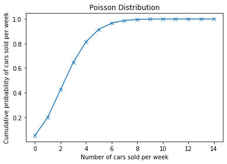

```python
plt.plot(n,poisson,'-x');
plt.title('Poisson Distribution')
plt.xlabel('Number of cars sold per week');
plt.ylabel('Cumulative probability of cars sold per week');
```

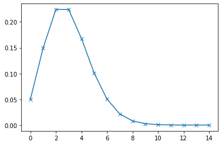

```python
plt.plot(n,poisson1,'-x');
```

### Answer 4

Recognition accuracy of the bot --> 86.8%. Hence, failure to recognize orders correctly is (100%-86.8%) or 13.2%

This is again binomial distribution question as below assumptions holding true..-

1. Number of trials are fixed,
2. Only two possible outcomes in all the trials.
3. Each trials are independent of each other
4. Probability of success of each trial is fixed

```python
k=np.arange(0,10)
n=3  # no. of trials
p = .132  #probability of not recognizing the order correctly
```

```python
binomial2=stats.binom.pmf(k=np.arange(0,10),n=3,p=.132)
binomial2
```

```
array([0.65397203, 0.2983559 , 0.0453721 , 0.00229997, 0.        ,
       0.        , 0.        , 0.        , 0.        , 0.        ])
```

##### Answer 4A: probability that all three orders will be recognised correctly is

```python
binomial2[0]
```

```
0.653972032
```

#### Answer 4B: probability that none of the three orders will be recognised correctly

```python
binomial2[3]
```

```
0.002299968
```

#### Answer 4C: probability that at least two of the three orders will be recognised correctly

```python
binomial2[0]+binomial2[1]
```

```
0.9523279359999999
```

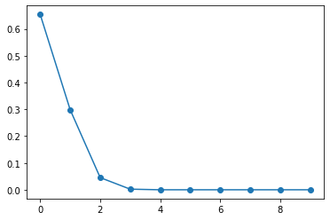

```python
plt.plot(binomial2,'-o');
```

### Answer 5

Possible applications for binomial distribution could be in Burger order taking and poisson distribution in Burger manufacturing process.

# Part B

### Answer 1

Case study on company (Management X) from Sports domain.

```python
df=pd.read_csv('C:/Users/RAMEYADA/OneDrive - Schenker AG/Documents/Study/Great Learning + University of Texas - AIML/Applied Statistics_Week 4 5 and 6 _ 18112022 to 18122022/Applied Statistics Project/DS+-+Part2+-+Basketball.csv')
```

```python
df.head()
```

|  | Team | Tournament | Score | PlayedGames | WonGames | DrawnGames | LostGames | BasketScored | BasketGiven | TournamentChampion | Runner-up | TeamLaunch | HighestPositionHeld |
| --- | --- | --- | --- | --- | --- | --- | --- | --- | --- | --- | --- | --- | --- |
| 0 | Team 1 | 86 | 4385 | 2762 | 1647 | 552 | 563 | 5947 | 3140 | 33 | 23 | 1929 | 1 |
| 1 | Team 2 | 86 | 4262 | 2762 | 1581 | 573 | 608 | 5900 | 3114 | 25 | 25 | 1929 | 1 |
| 2 | Team 3 | 80 | 3442 | 2614 | 1241 | 598 | 775 | 4534 | 3309 | 10 | 8 | 1929 | 1 |
| 3 | Team 4 | 82 | 3386 | 2664 | 1187 | 616 | 861 | 4398 | 3469 | 6 | 6 | 1931to32 | 1 |
| 4 | Team 5 | 86 | 3368 | 2762 | 1209 | 633 | 920 | 4631 | 3700 | 8 | 7 | 1929 | 1 |

```python
df.tail()
```

|  | Team | Tournament | Score | PlayedGames | WonGames | DrawnGames | LostGames | BasketScored | BasketGiven | TournamentChampion | Runner-up | TeamLaunch | HighestPositionHeld |
| --- | --- | --- | --- | --- | --- | --- | --- | --- | --- | --- | --- | --- | --- |
| 56 | Team 57 | 1 | 34 | 38 | 8 | 10 | 20 | 38 | 66 | - | - | 2009-10 | 20 |
| 57 | Team 58 | 1 | 22 | 30 | 7 | 8 | 15 | 37 | 57 | - | - | 1956-57 | 16 |
| 58 | Team 59 | 1 | 19 | 30 | 7 | 5 | 18 | 51 | 85 | - | - | 1951~52 | 16 |
| 59 | Team 60 | 1 | 14 | 30 | 5 | 4 | 21 | 34 | 65 | - | - | 1955-56 | 15 |
| 60 | Team 61 | 1 | - | - | - | - | - | - | - | - | - | 2017~18 | 9 |

```python
df.describe()
```

|  | Tournament | HighestPositionHeld |
| --- | --- | --- |
| count | 61.000000 | 61.000000 |
| mean | 24.000000 | 7.081967 |
| std | 26.827225 | 5.276663 |
| min | 1.000000 | 1.000000 |
| 25% | 4.000000 | 3.000000 |
| 50% | 12.000000 | 6.000000 |
| 75% | 38.000000 | 10.000000 |
| max | 86.000000 | 20.000000 |

```python
df.dtypes
```

```
Team                   object
Tournament              int64
Score                  object
PlayedGames            object
WonGames               object
DrawnGames             object
LostGames              object
BasketScored           object
BasketGiven            object
TournamentChampion     object
Runner-up              object
TeamLaunch             object
HighestPositionHeld     int64
dtype: object
```

```python
df.shape
```

```
(61, 13)
```

```python
df.iloc[3]
```

```
Team                     Team 4
Tournament                   82
Score                      3386
PlayedGames                2664
WonGames                   1187
DrawnGames                  616
LostGames                   861
BasketScored               4398
BasketGiven                3469
TournamentChampion            6
Runner-up                     6
TeamLaunch             1931to32
HighestPositionHeld           1
Name: 3, dtype: object
```

```python
df.set_index('Team',inplace=True)
```

```python
df.head()
```

| Team | Tournament | Score | PlayedGames | WonGames | DrawnGames | LostGames | BasketScored | BasketGiven | TournamentChampion | Runner-up | TeamLaunch | HighestPositionHeld |
| --- | --- | --- | --- | --- | --- | --- | --- | --- | --- | --- | --- | --- |
| Team 1 | 86 | 4385 | 2762 | 1647 | 552 | 563 | 5947 | 3140 | 33 | 23 | 1929 | 1 |
| Team 2 | 86 | 4262 | 2762 | 1581 | 573 | 608 | 5900 | 3114 | 25 | 25 | 1929 | 1 |
| Team 3 | 80 | 3442 | 2614 | 1241 | 598 | 775 | 4534 | 3309 | 10 | 8 | 1929 | 1 |
| Team 4 | 82 | 3386 | 2664 | 1187 | 616 | 861 | 4398 | 3469 | 6 | 6 | 1931to32 | 1 |
| Team 5 | 86 | 3368 | 2762 | 1209 | 633 | 920 | 4631 | 3700 | 8 | 7 | 1929 | 1 |

```python
df.shape
```

```
(61, 12)
```

```python
df.info()
```

```
<class 'pandas.core.frame.DataFrame'>
Index: 61 entries, Team 1 to Team 61
Data columns (total 12 columns):
 #   Column               Non-Null Count  Dtype
---  ------               --------------  -----
 0   Tournament           61 non-null     int64
 1   Score                61 non-null     object
 2   PlayedGames          61 non-null     object
 3   WonGames             61 non-null     object
 4   DrawnGames           61 non-null     object
 5   LostGames            61 non-null     object
 6   BasketScored         61 non-null     object
 7   BasketGiven          61 non-null     object
 8   TournamentChampion   61 non-null     object
 9   Runner-up            61 non-null     object
 10  TeamLaunch           61 non-null     object
 11  HighestPositionHeld  61 non-null     int64
dtypes: int64(2), object(10)
memory usage: 6.2+ KB
```

```python
df.head()
```

| Team | Tournament | Score | PlayedGames | WonGames | DrawnGames | LostGames | BasketScored | BasketGiven | TournamentChampion | Runner-up | TeamLaunch | HighestPositionHeld |
| --- | --- | --- | --- | --- | --- | --- | --- | --- | --- | --- | --- | --- |
| Team 1 | 86 | 4385 | 2762 | 1647 | 552 | 563 | 5947 | 3140 | 33 | 23 | 1929 | 1 |
| Team 2 | 86 | 4262 | 2762 | 1581 | 573 | 608 | 5900 | 3114 | 25 | 25 | 1929 | 1 |
| Team 3 | 80 | 3442 | 2614 | 1241 | 598 | 775 | 4534 | 3309 | 10 | 8 | 1929 | 1 |
| Team 4 | 82 | 3386 | 2664 | 1187 | 616 | 861 | 4398 | 3469 | 6 | 6 | 1931to32 | 1 |
| Team 5 | 86 | 3368 | 2762 | 1209 | 633 | 920 | 4631 | 3700 | 8 | 7 | 1929 | 1 |

```python
np.array(df.columns)
```

```
array(['Tournament', 'Score', 'PlayedGames', 'WonGames', 'DrawnGames',
       'LostGames', 'BasketScored', 'BasketGiven', 'TournamentChampion',
       'Runner-up', 'TeamLaunch', 'HighestPositionHeld'], dtype=object)
```

```python
df.BasketScored.value_counts().head()
```

```
70      2
2683    1
1753    1
2052    1
36      1
Name: BasketScored, dtype: int64
```

```python
df.tail()
```

| Team | Tournament | Score | PlayedGames | WonGames | DrawnGames | LostGames | BasketScored | BasketGiven | TournamentChampion | Runner-up | TeamLaunch | HighestPositionHeld |
| --- | --- | --- | --- | --- | --- | --- | --- | --- | --- | --- | --- | --- |
| Team 57 | 1 | 34 | 38 | 8 | 10 | 20 | 38 | 66 | - | - | 2009-10 | 20 |
| Team 58 | 1 | 22 | 30 | 7 | 8 | 15 | 37 | 57 | - | - | 1956-57 | 16 |
| Team 59 | 1 | 19 | 30 | 7 | 5 | 18 | 51 | 85 | - | - | 1951~52 | 16 |
| Team 60 | 1 | 14 | 30 | 5 | 4 | 21 | 34 | 65 | - | - | 1955-56 | 15 |
| Team 61 | 1 | - | - | - | - | - | - | - | - | - | 2017~18 | 9 |

```python
exp_df=df.loc[:,['TournamentChampion','Runner-up']].dropna() ## ignore this line - just for experimentation
```

```python
df.tail()
```

| Team | Tournament | Score | PlayedGames | WonGames | DrawnGames | LostGames | BasketScored | BasketGiven | TournamentChampion | Runner-up | TeamLaunch | HighestPositionHeld |
| --- | --- | --- | --- | --- | --- | --- | --- | --- | --- | --- | --- | --- |
| Team 57 | 1 | 34 | 38 | 8 | 10 | 20 | 38 | 66 | - | - | 2009-10 | 20 |
| Team 58 | 1 | 22 | 30 | 7 | 8 | 15 | 37 | 57 | - | - | 1956-57 | 16 |
| Team 59 | 1 | 19 | 30 | 7 | 5 | 18 | 51 | 85 | - | - | 1951~52 | 16 |
| Team 60 | 1 | 14 | 30 | 5 | 4 | 21 | 34 | 65 | - | - | 1955-56 | 15 |
| Team 61 | 1 | - | - | - | - | - | - | - | - | - | 2017~18 | 9 |

```python
df
```

| Team | Tournament | Score | PlayedGames | WonGames | DrawnGames | LostGames | BasketScored | BasketGiven | TournamentChampion | Runner-up | TeamLaunch | HighestPositionHeld |
| --- | --- | --- | --- | --- | --- | --- | --- | --- | --- | --- | --- | --- |
| Team 1 | 86 | 4385 | 2762 | 1647 | 552 | 563 | 5947 | 3140 | 33 | 23 | 1929 | 1 |
| Team 2 | 86 | 4262 | 2762 | 1581 | 573 | 608 | 5900 | 3114 | 25 | 25 | 1929 | 1 |
| Team 3 | 80 | 3442 | 2614 | 1241 | 598 | 775 | 4534 | 3309 | 10 | 8 | 1929 | 1 |
| Team 4 | 82 | 3386 | 2664 | 1187 | 616 | 861 | 4398 | 3469 | 6 | 6 | 1931to32 | 1 |
| Team 5 | 86 | 3368 | 2762 | 1209 | 633 | 920 | 4631 | 3700 | 8 | 7 | 1929 | 1 |
| ... | ... | ... | ... | ... | ... | ... | ... | ... | ... | ... | ... | ... |
| Team 57 | 1 | 34 | 38 | 8 | 10 | 20 | 38 | 66 | - | - | 2009-10 | 20 |
| Team 58 | 1 | 22 | 30 | 7 | 8 | 15 | 37 | 57 | - | - | 1956-57 | 16 |
| Team 59 | 1 | 19 | 30 | 7 | 5 | 18 | 51 | 85 | - | - | 1951~52 | 16 |
| Team 60 | 1 | 14 | 30 | 5 | 4 | 21 | 34 | 65 | - | - | 1955-56 | 15 |
| Team 61 | 1 | - | - | - | - | - | - | - | - | - | 2017~18 | 9 |

61 rows × 12 columns

```python
df['TeamLaunch'] = df.TeamLaunch.apply(lambda x : x.split(sep = '-')[0])
```

```python
df['TeamLaunch'] = df.TeamLaunch.apply(lambda x : x.split(sep = 'to')[0])
```

```python
df['TeamLaunch'] = df.TeamLaunch.apply(lambda x : x.split(sep = '~')[0])
```

```python
df['TeamLaunch'] = df.TeamLaunch.apply(lambda x : x.split(sep = '_')[0])
```

```python
df['TeamLaunch'].describe
```

```
<bound method NDFrame.describe of Team
Team 1     1929
Team 2     1929
Team 3     1929
Team 4     1931
Team 5     1929
           ...
Team 57    2009
Team 58    1956
Team 59    1951
Team 60    1955
Team 61    2017
Name: TeamLaunch, Length: 61, dtype: object>
```

```python
df.drop(['Team 61'],inplace=True)
df.shape
```

```
(60, 12)
```

```python
df['Runner-up'].replace('-',0,inplace=True)
df['TournamentChampion'].replace('-',0,inplace=True)
```

```python
df.dtypes
```

```
Tournament              int64
Score                  object
PlayedGames            object
WonGames               object
DrawnGames             object
LostGames              object
BasketScored           object
BasketGiven            object
TournamentChampion     object
Runner-up              object
TeamLaunch             object
HighestPositionHeld     int64
dtype: object
```

```python
df['Score']=df['Score'].astype('int64')
```

```python
df['PlayedGames']=df['PlayedGames'].astype('int64')
```

```python
df['WonGames']=df['WonGames'].astype('int64')
```

```python
df['DrawnGames']=df['DrawnGames'].astype('int64')
```

```python
df['LostGames']=df['LostGames'].astype('int64')
```

```python
df.dtypes
```

```
Tournament              int64
Score                   int64
PlayedGames             int64
WonGames                int64
DrawnGames              int64
LostGames               int64
BasketScored           object
BasketGiven            object
TournamentChampion     object
Runner-up              object
TeamLaunch             object
HighestPositionHeld     int64
dtype: object
```

```python
df = df.astype({'BasketScored':'int64'})
```

```python
df = df.astype({'BasketScored':'int64'})
```

```python
df = df.astype({'BasketGiven':'int64'})
```

```python
df = df.astype({'TournamentChampion':'int64'})
```

```python
df = df.astype({'Runner-up':'int64'})
```

```python
df = df.astype({'TeamLaunch':'int64'})
```

```python
df.dtypes
```

```
Tournament             int64
Score                  int64
PlayedGames            int64
WonGames               int64
DrawnGames             int64
LostGames              int64
BasketScored           int64
BasketGiven            int64
TournamentChampion     int64
Runner-up              int64
TeamLaunch             int64
HighestPositionHeld    int64
dtype: object
```

```
array([[<matplotlib.axes._subplots.AxesSubplot object at 0x000001A8A60E2848>,
      dtype=object)
```

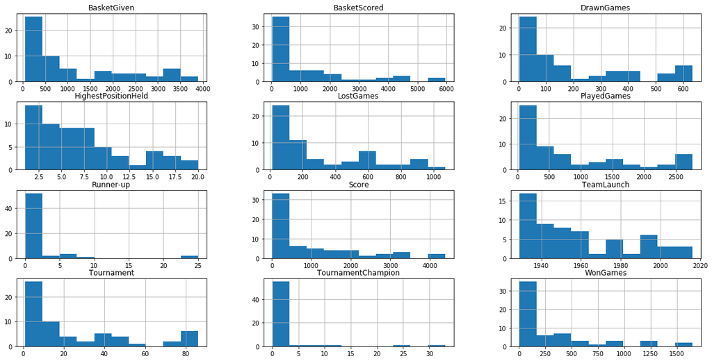

```python
df.hist(figsize=(20,10))
```

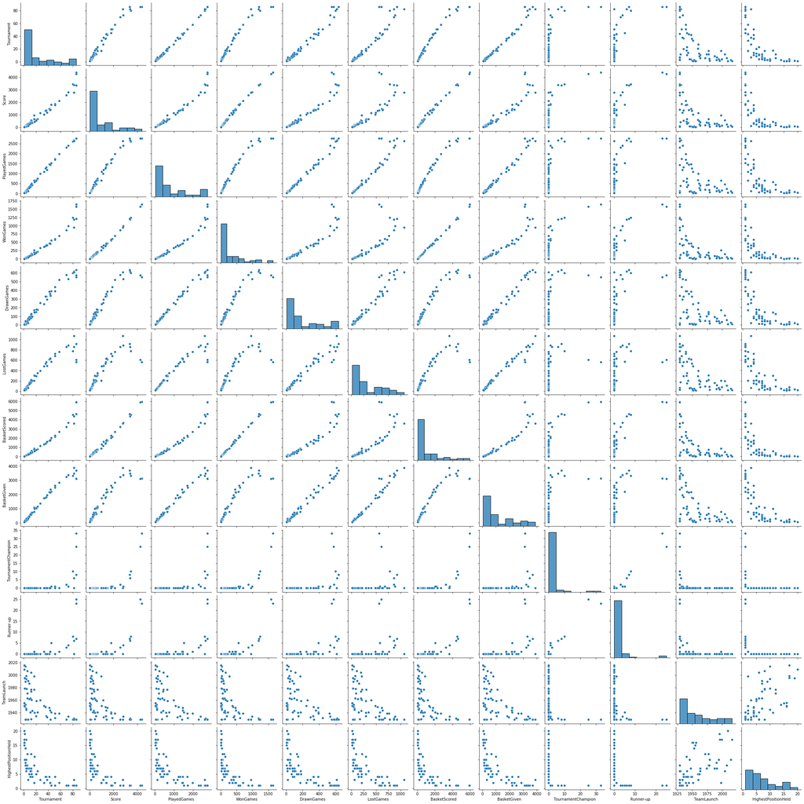

```python
sns.pairplot(df)
```

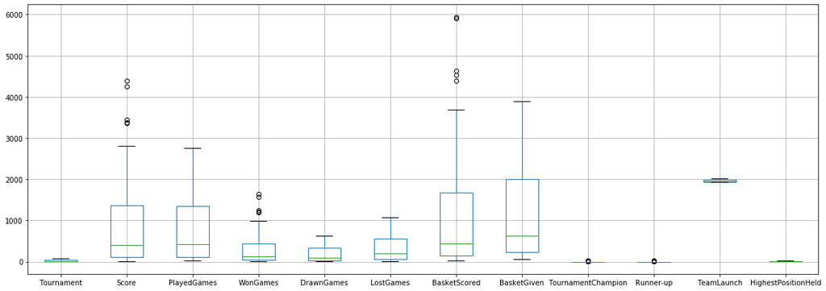

```python
df.boxplot(figsize=(20,7))
```

```
array([[<matplotlib.axes._subplots.AxesSubplot object at 0x000001A8ACB1B588>,
      dtype=object)
```

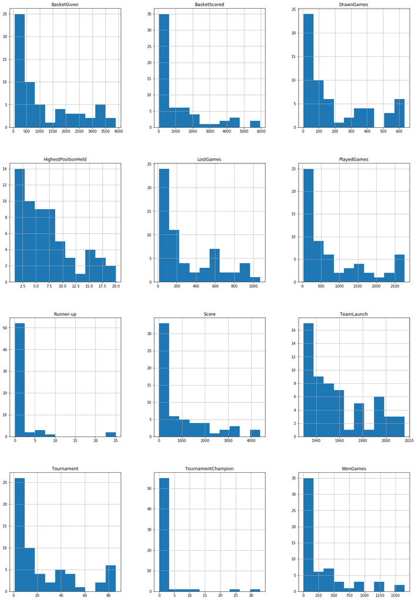

```python
df.hist(figsize=(20,30))
```

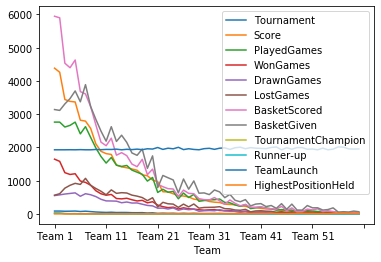

```python
df.plot(kind='line')
```

```python
corr = df.corr()
```

```python
corr
```

|  | Tournament | Score | PlayedGames | WonGames | DrawnGames | LostGames | BasketScored | BasketGiven | TournamentChampion | Runner-up | TeamLaunch | HighestPositionHeld |
| --- | --- | --- | --- | --- | --- | --- | --- | --- | --- | --- | --- | --- |
| Tournament | 1.000000 | 0.981258 | 0.998683 | 0.971749 | 0.989295 | 0.949350 | 0.974867 | 0.987781 | 0.589304 | 0.645924 | -0.599166 | -0.708002 |
| Score | 0.981258 | 1.000000 | 0.979687 | 0.997232 | 0.958090 | 0.878780 | 0.996634 | 0.943801 | 0.715014 | 0.764819 | -0.538542 | -0.669215 |
| PlayedGames | 0.998683 | 0.979687 | 1.000000 | 0.967486 | 0.993972 | 0.955925 | 0.969970 | 0.990020 | 0.575072 | 0.633101 | -0.581243 | -0.711065 |
| WonGames | 0.971749 | 0.997232 | 0.967486 | 1.000000 | 0.939416 | 0.851436 | 0.999312 | 0.925745 | 0.752904 | 0.797849 | -0.540421 | -0.647819 |
| DrawnGames | 0.989295 | 0.958090 | 0.993972 | 0.939416 | 1.000000 | 0.972786 | 0.942234 | 0.992479 | 0.503378 | 0.566021 | -0.570175 | -0.720248 |
| LostGames | 0.949350 | 0.878780 | 0.955925 | 0.851436 | 0.972786 | 1.000000 | 0.857843 | 0.985041 | 0.324025 | 0.391645 | -0.591571 | -0.726172 |
| BasketScored | 0.974867 | 0.996634 | 0.969970 | 0.999312 | 0.942234 | 0.857843 | 1.000000 | 0.931079 | 0.743847 | 0.791041 | -0.550150 | -0.648672 |
| BasketGiven | 0.987781 | 0.943801 | 0.990020 | 0.925745 | 0.992479 | 0.985041 | 0.931079 | 1.000000 | 0.471618 | 0.533448 | -0.608902 | -0.727323 |
| TournamentChampion | 0.589304 | 0.715014 | 0.575072 | 0.752904 | 0.503378 | 0.324025 | 0.743847 | 0.471618 | 1.000000 | 0.971533 | -0.286768 | -0.304307 |
| Runner-up | 0.645924 | 0.764819 | 0.633101 | 0.797849 | 0.566021 | 0.391645 | 0.791041 | 0.533448 | 0.971533 | 1.000000 | -0.317250 | -0.359191 |
| TeamLaunch | -0.599166 | -0.538542 | -0.581243 | -0.540421 | -0.570175 | -0.591571 | -0.550150 | -0.608902 | -0.286768 | -0.317250 | 1.000000 | 0.599679 |
| HighestPositionHeld | -0.708002 | -0.669215 | -0.711065 | -0.647819 | -0.720248 | -0.726172 | -0.648672 | -0.727323 | -0.304307 | -0.359191 | 0.599679 | 1.000000 |

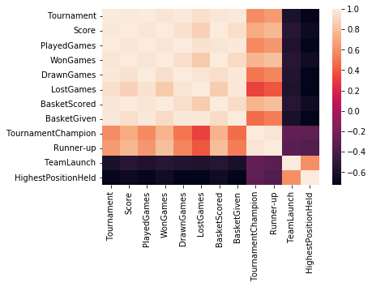

```python
sns.heatmap(corr)
```

```python
df.tail()
```

| Team | Tournament | Score | PlayedGames | WonGames | DrawnGames | LostGames | BasketScored | BasketGiven | TournamentChampion | Runner-up | TeamLaunch | HighestPositionHeld |
| --- | --- | --- | --- | --- | --- | --- | --- | --- | --- | --- | --- | --- |
| Team 56 | 1 | 35 | 38 | 8 | 11 | 19 | 36 | 55 | 0 | 0 | 2016 | 17 |
| Team 57 | 1 | 34 | 38 | 8 | 10 | 20 | 38 | 66 | 0 | 0 | 2009 | 20 |
| Team 58 | 1 | 22 | 30 | 7 | 8 | 15 | 37 | 57 | 0 | 0 | 1956 | 16 |
| Team 59 | 1 | 19 | 30 | 7 | 5 | 18 | 51 | 85 | 0 | 0 | 1951 | 16 |
| Team 60 | 1 | 14 | 30 | 5 | 4 | 21 | 34 | 65 | 0 | 0 | 1955 | 15 |

```python
df.dtypes
```

```
Tournament             int64
Score                  int64
PlayedGames            int64
WonGames               int64
DrawnGames             int64
LostGames              int64
BasketScored           int64
BasketGiven            int64
TournamentChampion     int64
Runner-up              int64
TeamLaunch             int64
HighestPositionHeld    int64
dtype: object
```

### Answer 2

Exploratory Data Analysis using univariate and bivariate analysis.

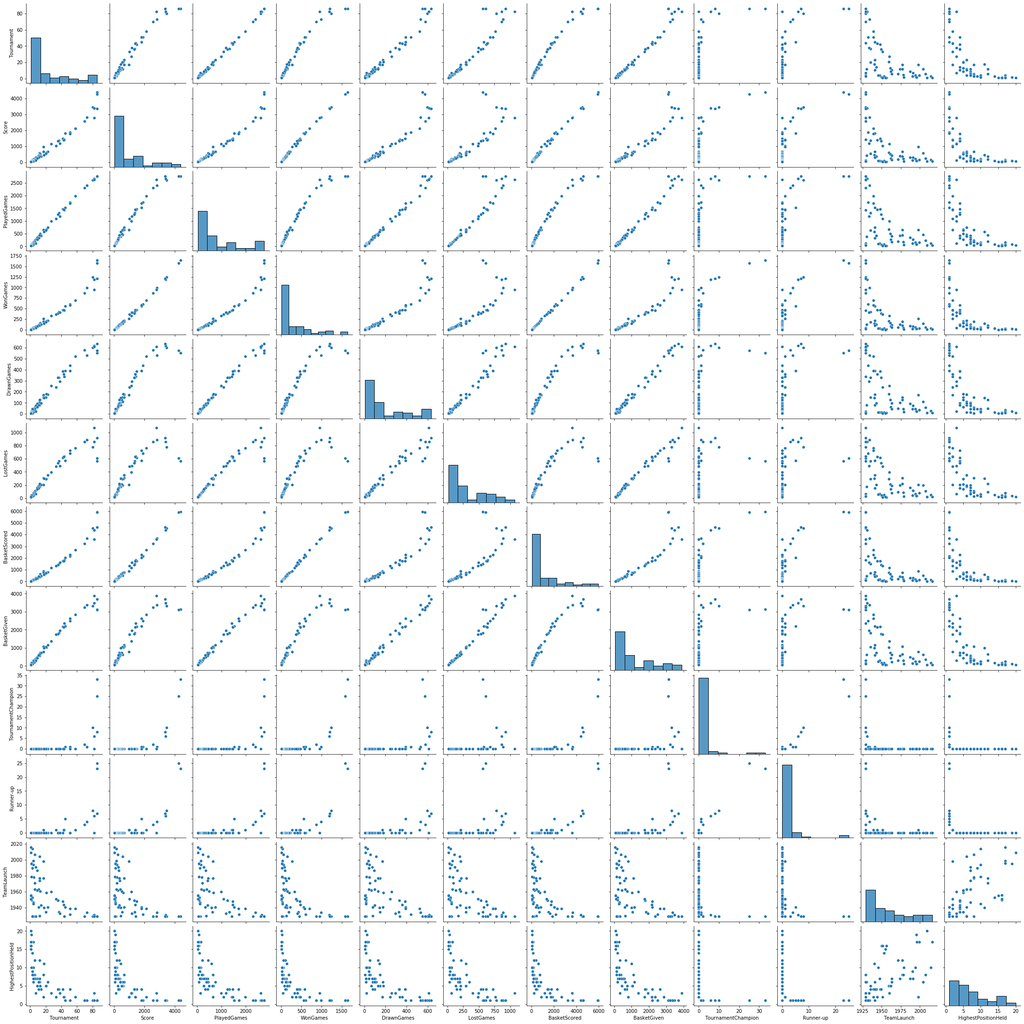

```python
sns.pairplot(df)
```

```python
df.isna().apply(pd.value_counts)
```

|  | Tournament | Score | PlayedGames | WonGames | DrawnGames | LostGames | BasketScored | BasketGiven | TournamentChampion | Runner-up | TeamLaunch | HighestPositionHeld |
| --- | --- | --- | --- | --- | --- | --- | --- | --- | --- | --- | --- | --- |
| False | 60 | 60 | 60 | 60 | 60 | 60 | 60 | 60 | 60 | 60 | 60 | 60 |

```python
df.head()
```

| Team | Tournament | Score | PlayedGames | WonGames | DrawnGames | LostGames | BasketScored | BasketGiven | TournamentChampion | Runner-up | TeamLaunch | HighestPositionHeld |
| --- | --- | --- | --- | --- | --- | --- | --- | --- | --- | --- | --- | --- |
| Team 1 | 86 | 4385 | 2762 | 1647 | 552 | 563 | 5947 | 3140 | 33 | 23 | 1929 | 1 |
| Team 2 | 86 | 4262 | 2762 | 1581 | 573 | 608 | 5900 | 3114 | 25 | 25 | 1929 | 1 |
| Team 3 | 80 | 3442 | 2614 | 1241 | 598 | 775 | 4534 | 3309 | 10 | 8 | 1929 | 1 |
| Team 4 | 82 | 3386 | 2664 | 1187 | 616 | 861 | 4398 | 3469 | 6 | 6 | 1931 | 1 |
| Team 5 | 86 | 3368 | 2762 | 1209 | 633 | 920 | 4631 | 3700 | 8 | 7 | 1929 | 1 |

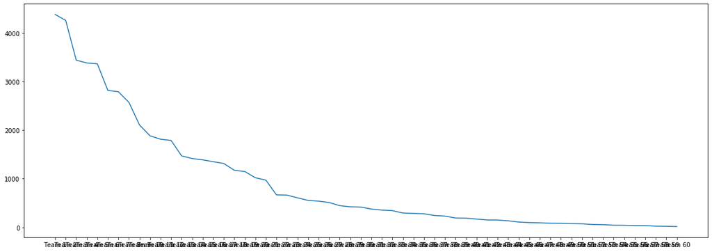

```python
plt.figure(figsize=(20,7))
plt.plot(df['Score']);
```

```python
df['Score'].max
```

```
<bound method Series.max of Team
Team 1     4385
Team 2     4262
Team 3     3442
Team 4     3386
Team 5     3368
Team 6     2819
Team 7     2792
Team 8     2573
Team 9     2109
Team 10    1884
Team 11    1814
Team 12    1789
Team 13    1471
Team 14    1416
Team 15    1389
Team 16    1351
Team 17    1314
Team 18    1174
Team 19    1148
Team 20    1020
Team 21     970
Team 22     667
Team 23     662
Team 24     606
Team 25     553
Team 26     538
Team 27     510
Team 28     445
Team 29     421
Team 30     416
Team 31     375
Team 32     353
Team 33     343
Team 34     293
Team 35     285
Team 36     277
Team 37     242
Team 38     230
Team 39     190
Team 40     188
Team 41     168
Team 42     150
Team 43     148
Team 44     132
Team 45     107
Team 46      96
Team 47      91
Team 48      83
Team 49      81
Team 50      76
Team 51      71
Team 52      56
Team 53      52
Team 54      42
Team 55      40
Team 56      35
Team 57      34
Team 58      22
Team 59      19
Team 60      14
Name: Score, dtype: int64>
```

```python
df.loc['Team 1']
```

```
Tournament               86
Score                  4385
PlayedGames            2762
WonGames               1647
DrawnGames              552
LostGames               563
BasketScored           5947
BasketGiven            3140
TournamentChampion       33
Runner-up                23
TeamLaunch             1929
HighestPositionHeld       1
Name: Team 1, dtype: int64
```

```python
df['TeamLaunch'].sort_values
```

```
<bound method Series.sort_values of Team
Team 1     1929
Team 2     1929
Team 3     1929
Team 4     1931
Team 5     1929
Team 6     1934
Team 7     1929
Team 8     1929
Team 9     1939
Team 10    1932
Team 11    1941
Team 12    1939
Team 13    1948
Team 14    1929
Team 15    1944
Team 16    1935
Team 17    1949
Team 18    1933
Team 19    1960
Team 20    1951
Team 21    1998
Team 22    1941
Team 23    1977
Team 24    1959
Team 25    2004
Team 26    1935
Team 27    1961
Team 28    1940
Team 29    1930
Team 30    1963
Team 31    1974
Team 32    1943
Team 33    1977
Team 34    1987
Team 35    1941
Team 36    1991
Team 37    2007
Team 38    1962
Team 39    1994
Team 40    1978
Team 41    1971
Team 42    1963
Team 43    1999
Team 44    2014
Team 45    1929
Team 46    1990
Team 47    1947
Team 48    1996
Team 49    1995
Team 50    1945
Team 51    1953
Team 52    1929
Team 53    1979
Team 54    1929
Team 55    1950
Team 56    2016
Team 57    2009
Team 58    1956
Team 59    1951
Team 60    1955
Name: TeamLaunch, dtype: int64>
```

```python
df.head()
```

| Team | Tournament | Score | PlayedGames | WonGames | DrawnGames | LostGames | BasketScored | BasketGiven | TournamentChampion | Runner-up | TeamLaunch | HighestPositionHeld |
| --- | --- | --- | --- | --- | --- | --- | --- | --- | --- | --- | --- | --- |
| Team 1 | 86 | 4385 | 2762 | 1647 | 552 | 563 | 5947 | 3140 | 33 | 23 | 1929 | 1 |
| Team 2 | 86 | 4262 | 2762 | 1581 | 573 | 608 | 5900 | 3114 | 25 | 25 | 1929 | 1 |
| Team 3 | 80 | 3442 | 2614 | 1241 | 598 | 775 | 4534 | 3309 | 10 | 8 | 1929 | 1 |
| Team 4 | 82 | 3386 | 2664 | 1187 | 616 | 861 | 4398 | 3469 | 6 | 6 | 1931 | 1 |
| Team 5 | 86 | 3368 | 2762 | 1209 | 633 | 920 | 4631 | 3700 | 8 | 7 | 1929 | 1 |

```python
df['WonGames'].sort_values()
```

```
Team
Team 60       5
Team 59       7
Team 58       7
Team 57       8
Team 56       8
Team 55      13
Team 53      17
Team 54      18
Team 49      19
Team 48      20
Team 52      21
Team 46      26
Team 51      29
Team 50      30
Team 47      34
Team 44      35
Team 43      37
Team 45      43
Team 40      50
Team 39      52
Team 42      53
Team 41      59
Team 37      62
Team 36      76
Team 38      82
Team 34      96
Team 35     103
Team 33     104
Team 30     113
Team 31     123
Team 29     125
Team 32     129
Team 28     145
Team 25     147
Team 27     155
Team 26     184
Team 23     189
Team 24     203
Team 22     218
Team 21     266
Team 19     333
Team 20     367
Team 17     390
Team 18     408
Team 16     426
Team 14     453
Team 13     463
Team 15     471
Team 11     563
Team 12     586
Team 10     606
Team 9      698
Team 8      864
Team 7      948
Team 6      990
Team 4     1187
Team 5     1209
Team 3     1241
Team 2     1581
Team 1     1647
Name: WonGames, dtype: int64
```

```python
df['BasketScored'].sort_values()
```

```
Team
Team 60      34
Team 56      36
Team 58      37
Team 57      38
Team 59      51
Team 48      62
Team 49      70
Team 55      70
Team 53      71
Team 54      97
Team 46     101
Team 51     121
Team 44     139
Team 50     145
Team 52     153
Team 43     155
Team 42     165
Team 47     181
Team 39     199
Team 40     202
Team 41     216
Team 45     227
Team 37     244
Team 38     285
Team 34     291
Team 36     320
Team 33     393
Team 35     419
Team 31     422
Team 30     430
Team 29     458
Team 32     492
Team 25     520
Team 28     607
Team 27     619
Team 26     716
Team 24     750
Team 23     760
Team 22     819
Team 21     892
Team 19    1182
Team 20    1347
Team 17    1421
Team 16    1500
Team 18    1642
Team 15    1753
Team 13    1767
Team 14    1843
Team 11    2052
Team 10    2159
Team 12    2278
Team 9     2683
Team 8     3228
Team 7     3609
Team 6     3680
Team 4     4398
Team 3     4534
Team 5     4631
Team 2     5900
Team 1     5947
Name: BasketScored, dtype: int64
```

```python
df['Runner-up'].sort_values()
```

```
Team
Team 30     0
Team 33     0
Team 34     0
Team 35     0
Team 36     0
Team 37     0
Team 38     0
Team 39     0
Team 40     0
Team 41     0
Team 42     0
Team 43     0
Team 44     0
Team 32     0
Team 45     0
Team 47     0
Team 48     0
Team 49     0
Team 50     0
Team 51     0
Team 52     0
Team 53     0
Team 54     0
Team 55     0
Team 56     0
Team 57     0
Team 58     0
Team 46     0
Team 31     0
Team 60     0
Team 29     0
Team 10     0
Team 59     0
Team 16     0
Team 17     0
Team 18     0
Team 19     0
Team 13     0
Team 7      0
Team 23     0
Team 24     0
Team 25     0
Team 26     0
Team 27     0
Team 28     0
Team 22     0
Team 12     0
Team 9      1
Team 15     1
Team 14     1
Team 20     1
Team 21     1
Team 8      3
Team 6      4
Team 11     5
Team 4      6
Team 5      7
Team 3      8
Team 1     23
Team 2     25
Name: Runner-up, dtype: int64
```